# Project Foundations for Data Science: FoodHub Data Analysis

# Cuisine

```
Number of unique cuisine types: 14
```

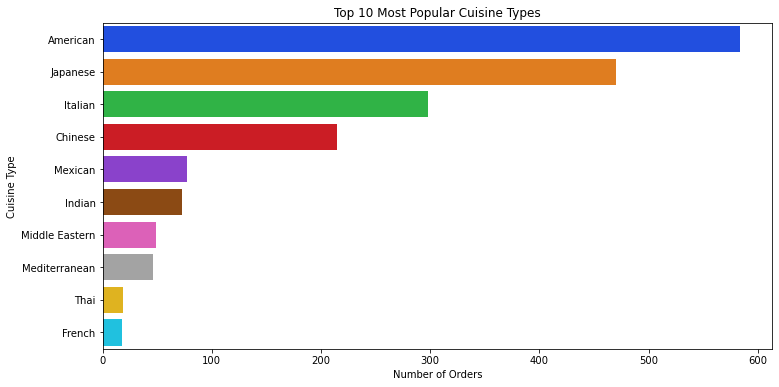

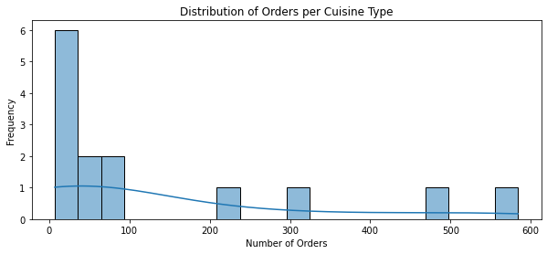

```python
# Check unique cuisine types
unique_cuisine_types = df['cuisine_type'].nunique()
print(f"Number of unique cuisine types: {unique_cuisine_types}")

# Check the frequency of each cuisine type
cuisine_counts = df['cuisine_type'].value_counts()

# Plot the top 10 most popular cuisine types
import matplotlib.pyplot as plt
import seaborn as sns

plt.figure(figsize=(12, 6))
sns.barplot(y=cuisine_counts.head(10).index, x=cuisine_counts.head(10).values, palette='bright')
plt.title('Top 10 Most Popular Cuisine Types')
plt.xlabel('Number of Orders')
plt.ylabel('Cuisine Type')
plt.show()

# Plot the distribution of cuisine types
plt.figure(figsize=(10, 4))
sns.histplot(cuisine_counts, bins=20, kde=True)
plt.title('Distribution of Orders per Cuisine Type')
plt.xlabel('Number of Orders')
plt.ylabel('Frequency')
plt.show()
```

Observation: Bar Plot Shows which type of foods are more popular than most which is American. The histogram shows the distribution where only a few cuisines dominate the number of orders.

# Cost Of The Order

```
count    1898.000000
mean       16.498851
std         7.483812
min         4.470000
25%        12.080000
50%        14.140000
75%        22.297500
max        35.410000
Name: cost_of_the_order, dtype: float64
```

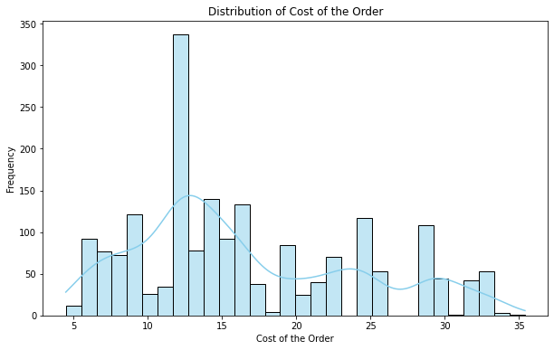

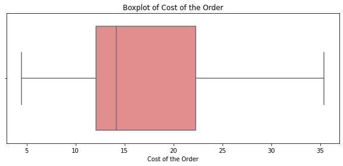

```python
# Summary statistics for cost of the order
cost_summary = df['cost_of_the_order'].describe()
print(cost_summary)

# Plotting the distribution of cost of the order
import matplotlib.pyplot as plt
import seaborn as sns

plt.figure(figsize=(10, 6))
sns.histplot(df['cost_of_the_order'], bins=30, kde=True, color='skyblue')
plt.title('Distribution of Cost of the Order')
plt.xlabel('Cost of the Order')
plt.ylabel('Frequency')
plt.show()

# Boxplot to identify outliers
plt.figure(figsize=(10, 4))
sns.boxplot(x=df['cost_of_the_order'], color='lightcoral')
plt.title('Boxplot of Cost of the Order')
plt.xlabel('Cost of the Order')
plt.show()
```

Observations: The histogram shows the distribution of the cost of orders from certain restaurants to others.  
The boxplot shows the percentiles and median cost of orders for all restaurants. The code df.desribe() gives the information the boxplot is showing.

# Day Of The Week

```
Number of unique day categories: 2
```

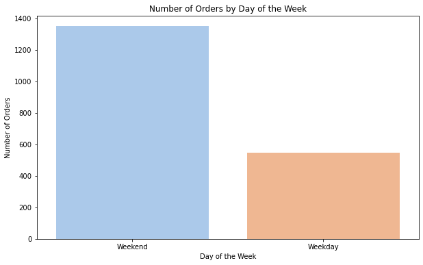

```python
# Check unique days of the week
unique_days = df['day_of_the_week'].nunique()
print(f"Number of unique day categories: {unique_days}")

# Check the frequency of orders for each day
day_counts = df['day_of_the_week'].value_counts()

# Plot the frequency of orders by day of the week
import matplotlib.pyplot as plt
import seaborn as sns

plt.figure(figsize=(10, 6))
sns.barplot(x=day_counts.index, y=day_counts.values, palette='pastel')
plt.title('Number of Orders by Day of the Week')
plt.xlabel('Day of the Week')
plt.ylabel('Number of Orders')
plt.show()
```

```python
# Check the frequency of orders for each day
day_counts = df['day_of_the_week'].value_counts()

# Display the counts
print(day_counts)
```

```
Weekend    1351
Weekday     547
Name: day_of_the_week, dtype: int64
```

The Weekend is typically where most customers go make orders from these resturants. The Weekend is around 1350 orders and weekday being around 500 orders.

# Rating

```
Number of unique ratings: 4
```

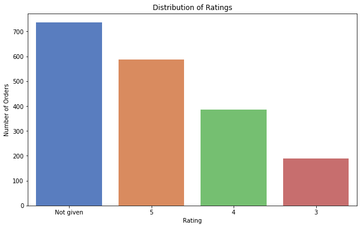

```python
# Check unique ratings
unique_ratings = df['rating'].nunique()
print(f"Number of unique ratings: {unique_ratings}")

# Check the frequency of each rating
rating_counts = df['rating'].value_counts()

# Plot the frequency of ratings
import matplotlib.pyplot as plt
import seaborn as sns

plt.figure(figsize=(10, 6))
sns.barplot(x=rating_counts.index, y=rating_counts.values, palette='muted')
plt.title('Distribution of Ratings')
plt.xlabel('Rating')
plt.ylabel('Number of Orders')
plt.show()
```

```python
# Check the frequency of orders for each day
ratings_counts = df['rating'].value_counts()

# Display the counts
print(ratings_counts)
```

```
Not given    736
5            588
4            386
3            188
Name: rating, dtype: int64
```

Observation: Many people don't leave a rating compared to rating stores a 3,4, of 5.

# Food Preparation Time

```
count    1898.000000
mean       27.371970
std         4.632481
min        20.000000
25%        23.000000
50%        27.000000
75%        31.000000
max        35.000000
Name: food_preparation_time, dtype: float64
```

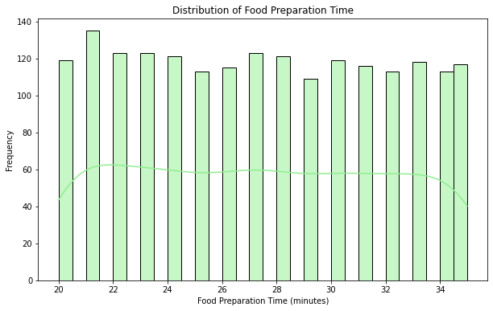

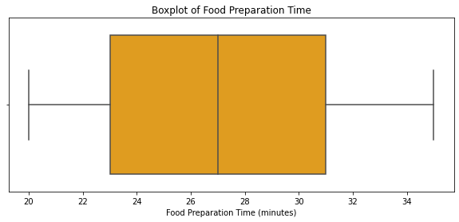

```python
# Summary statistics for food preparation time
prep_time_summary = df['food_preparation_time'].describe()
print(prep_time_summary)

# Plotting the distribution of food preparation time
import matplotlib.pyplot as plt
import seaborn as sns

plt.figure(figsize=(10, 6))
sns.histplot(df['food_preparation_time'], bins=30, kde=True, color='lightgreen')
plt.title('Distribution of Food Preparation Time')
plt.xlabel('Food Preparation Time (minutes)')
plt.ylabel('Frequency')
plt.show()

# Boxplot to identify outliers
plt.figure(figsize=(10, 4))
sns.boxplot(x=df['food_preparation_time'], color='orange')
plt.title('Boxplot of Food Preparation Time')
plt.xlabel('Food Preparation Time (minutes)')
plt.show()
```

# Delivery Time

```
count    1898.000000
mean       24.161749
std         4.972637
min        15.000000
25%        20.000000
50%        25.000000
75%        28.000000
max        33.000000
Name: delivery_time, dtype: float64
```

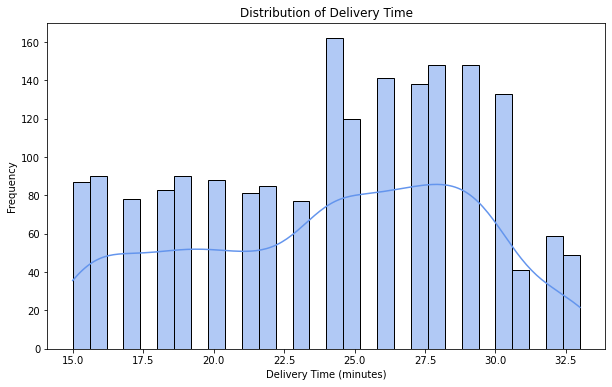

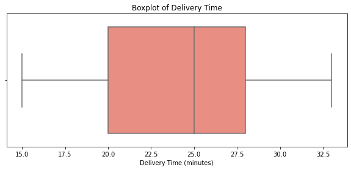

```python
# Summary statistics for delivery time
delivery_time_summary = df['delivery_time'].describe()
print(delivery_time_summary)

# Plotting the distribution of delivery time
import matplotlib.pyplot as plt
import seaborn as sns

plt.figure(figsize=(10, 6))
sns.histplot(df['delivery_time'], bins=30, kde=True, color='cornflowerblue')
plt.title('Distribution of Delivery Time')
plt.xlabel('Delivery Time (minutes)')
plt.ylabel('Frequency')
plt.show()

# Boxplot to identify outliers
plt.figure(figsize=(10, 4))
sns.boxplot(x=df['delivery_time'], color='salmon')
plt.title('Boxplot of Delivery Time')
plt.xlabel('Delivery Time (minutes)')
plt.show()
```

Delivery times are between 20 mintues to 27.5 with 25 being the most common. Boxplot shows the median being at 25.

### **Question 7**: Which are the top 5 restaurants in terms of the number of orders received? [1 mark]

```
Shake Shack                  219
The Meatball Shop            132
Blue Ribbon Sushi            119
Blue Ribbon Fried Chicken     96
Parm                          68
Name: restaurant_name, dtype: int64
```

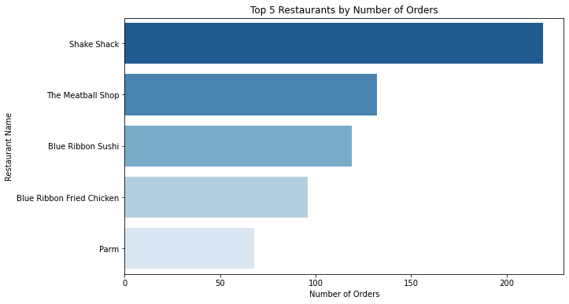

```python
# Top 5 restaurants based on the number of orders received
top_5_restaurants = df['restaurant_name'].value_counts().head(5)

# Display the top 5 restaurants
print(top_5_restaurants)

# Plotting the top 5 restaurants
import matplotlib.pyplot as plt
import seaborn as sns

plt.figure(figsize=(10, 6))
sns.barplot(y=top_5_restaurants.index, x=top_5_restaurants.values, palette='Blues_r')
plt.title('Top 5 Restaurants by Number of Orders')
plt.xlabel('Number of Orders')
plt.ylabel('Restaurant Name')
plt.show()
```

#### Observations:

Shake Shack, The Meatball Shop, Blue Ribbon Sushi, Blue Ribbon Fried Chicken and Parm are the top 5.

### **Question 8**: Which is the most popular cuisine on weekends? [1 mark]

```
The most popular cuisine on weekends is American with 415 orders.
```

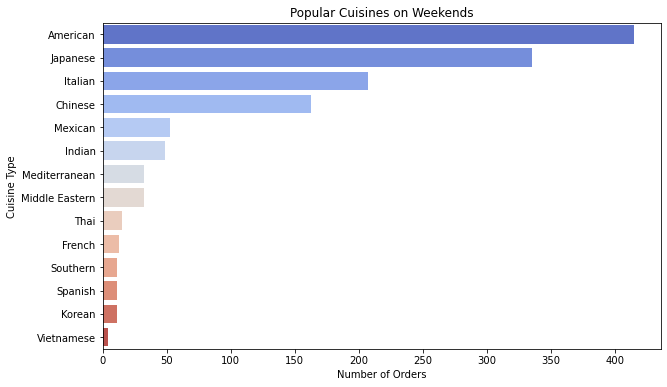

```python
# Filter data for weekends
weekend_data = df[df['day_of_the_week'] == 'Weekend']

# Find the most popular cuisine on weekends
most_popular_cuisine_weekend = weekend_data['cuisine_type'].value_counts().idxmax()
most_popular_cuisine_count = weekend_data['cuisine_type'].value_counts().max()

# Display the result
print(f"The most popular cuisine on weekends is {most_popular_cuisine_weekend} with {most_popular_cuisine_count} orders.")

# Plotting the top cuisines on weekends
import matplotlib.pyplot as plt
import seaborn as sns

plt.figure(figsize=(10, 6))
sns.barplot(y=weekend_data['cuisine_type'].value_counts().index,
            x=weekend_data['cuisine_type'].value_counts().values,
            palette='coolwarm')

plt.title('Popular Cuisines on Weekends')
plt.xlabel('Number of Orders')
plt.ylabel('Cuisine Type')
plt.show()
```

#### Observations:

American

### **Question 9**: What percentage of the orders cost more than 20 dollars? [2 marks]

```python
# Calculate the number of orders that cost more than $20
orders_above_20 = df[df['cost_of_the_order'] > 20].shape[0]

# Calculate the total number of orders
total_orders = df.shape[0]

# Calculate the percentage
percentage_above_20 = (orders_above_20 / total_orders) * 100

# Display the result
print(f"Percentage of orders costing more than $20: {percentage_above_20:.2f}%")
```

```
Percentage of orders costing more than $20: 29.24%
```

#### Observations:

About 29% of orders cost more than $20

### **Question 10**: What is the mean order delivery time? [1 mark]

```python
# Calculate the mean order delivery time
mean_delivery_time = df['delivery_time'].mean()

# Display the result
print(f"Mean Order Delivery Time: {mean_delivery_time:.2f} minutes")
```

```
Mean Order Delivery Time: 24.16 minutes
```

#### Observations:

Average delivery time is about 24 minutes

### **Question 11:** The company has decided to give 20% discount vouchers to the top 3 most frequent customers. Find the IDs of these customers and the number of orders they placed. [1 mark]

```python
# Find the top 3 most frequent customers
top_3_customers = df['customer_id'].value_counts().head(3)

# Display the result
print(top_3_customers)
```

```
52832    13
47440    10
83287     9
Name: customer_id, dtype: int64
```

#### Observation

These are the top three customers and the amount of times they ordered

### **Question 12**: Perform a multivariate analysis to explore relationships between the important variables in the dataset. (It is a good idea to explore relations between numerical variables as well as relations between numerical and categorical variables) [10 marks]

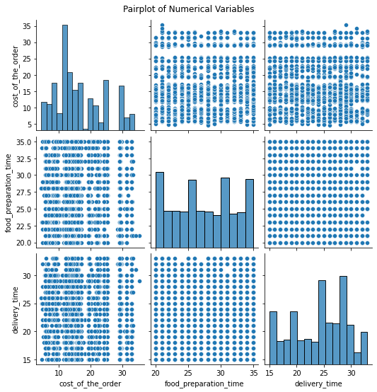

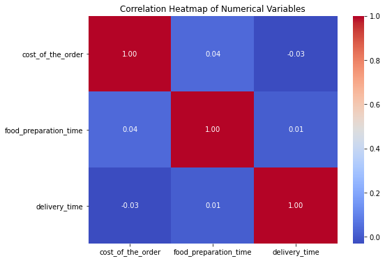

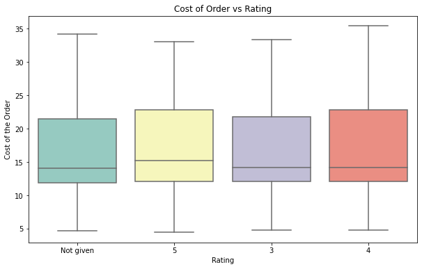

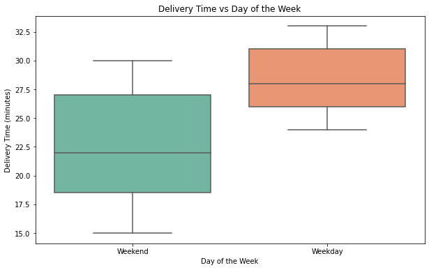

```python
import matplotlib.pyplot as plt
import seaborn as sns

# Pairplot to explore relationships between numerical variables
sns.pairplot(df[['cost_of_the_order', 'food_preparation_time', 'delivery_time']], diag_kind='hist')
plt.suptitle('Pairplot of Numerical Variables', y=1.02)
plt.show()

# Heatmap to visualize correlation between numerical variables
plt.figure(figsize=(8, 6))
correlation_matrix = df[['cost_of_the_order', 'food_preparation_time', 'delivery_time']].corr()
sns.heatmap(correlation_matrix, annot=True, cmap='coolwarm', fmt=".2f")
plt.title('Correlation Heatmap of Numerical Variables')
plt.show()

# Boxplot to explore the relationship between cost and rating
plt.figure(figsize=(10, 6))
sns.boxplot(x='rating', y='cost_of_the_order', data=df, palette='Set3')
plt.title('Cost of Order vs Rating')
plt.xlabel('Rating')
plt.ylabel('Cost of the Order')
plt.show()

# Boxplot to explore the relationship between day of the week and delivery time
plt.figure(figsize=(10, 6))
sns.boxplot(x='day_of_the_week', y='delivery_time', data=df, palette='Set2')
plt.title('Delivery Time vs Day of the Week')
plt.xlabel('Day of the Week')
plt.ylabel('Delivery Time (minutes)')
plt.show()
```

### **Question 13:** The company wants to provide a promotional offer in the advertisement of the restaurants. The condition to get the offer is that the restaurants must have a rating count of more than 50 and the average rating should be greater than 4. Find the restaurants fulfilling the criteria to get the promotional offer. [3 marks]

```python
# Fixing the SettingWithCopyWarning by using .copy()
df_filtered = df[df['rating'] != 'Not given'].copy()

# Converting rating to numeric
df_filtered.loc[:, 'rating'] = pd.to_numeric(df_filtered['rating'])

# Group by restaurant to get rating count and average rating
restaurant_ratings = df_filtered.groupby('restaurant_name')['rating'].agg(['count', 'mean'])

# Apply the promotional offer conditions
eligible_restaurants = restaurant_ratings[(restaurant_ratings['count'] > 50) & (restaurant_ratings['mean'] > 4)]

# Display eligible restaurants
print(eligible_restaurants)
```

```
                           count      mean
restaurant_name
Blue Ribbon Fried Chicken     64  4.328125
Blue Ribbon Sushi             73  4.219178
Shake Shack                  133  4.278195
The Meatball Shop             84  4.511905
```

#### Observations:

Four restaurants are eligible for the promotion offer. Count shows the average rating and the amount of ratings that restaurants have received. Shake Shack has the most ratings, while The Meatball Shop has the highest average.

### **Question 14:** The company charges the restaurant 25% on the orders having cost greater than 20 dollars and 15% on the orders having cost greater than 5 dollars. Find the net revenue generated by the company across all orders. [3 marks]

```python
# Calculate the revenue from orders costing more than $20 (25% charge)
revenue_above_20 = df[df['cost_of_the_order'] > 20]['cost_of_the_order'].apply(lambda x: x * 0.25).sum()

# Calculate the revenue from orders costing more than $5 but less than or equal to $20 (15% charge)
revenue_between_5_and_20 = df[(df['cost_of_the_order'] > 5) & (df['cost_of_the_order'] <= 20)]['cost_of_the_order'].apply(lambda x: x * 0.15).sum()

# Total revenue
net_revenue = revenue_above_20 + revenue_between_5_and_20

# Display the net revenue
print(f"Net Revenue Generated by the Company: ${net_revenue:.2f}")
```

```
Net Revenue Generated by the Company: $6166.30
```

#### Observations:

The total revenue from both fees was $6166.30

### **Question 15:** The company wants to analyze the total time required to deliver the food. What percentage of orders take more than 60 minutes to get delivered from the time the order is placed? (The food has to be prepared and then delivered.) [2 marks]

```python
# Calculate the total time for each order (preparation time + delivery time)
df['total_delivery_time'] = df['food_preparation_time'] + df['delivery_time']

# Calculate the number of orders that took more than 60 minutes
orders_above_60 = df[df['total_delivery_time'] > 60].shape[0]

# Calculate the total number of orders
total_orders = df.shape[0]

# Calculate the percentage of orders taking more than 60 minutes
percentage_above_60 = (orders_above_60 / total_orders) * 100

# Display the result
print(f"Percentage of orders taking more than 60 minutes: {percentage_above_60:.2f}%")
```

```
Percentage of orders taking more than 60 minutes: 10.54%
```

#### Observations:

Code shows that 10% of orders take over an hour

### **Question 16:** The company wants to analyze the delivery time of the orders on weekdays and weekends. How does the mean delivery time vary during weekdays and weekends? [2 marks]

```python
# Calculate the mean delivery time for weekdays and weekends
mean_delivery_time_by_day = df.groupby('day_of_the_week')['delivery_time'].mean()

# Display the result
print(mean_delivery_time_by_day)
```

```
day_of_the_week
Weekday    28.340037
Weekend    22.470022
Name: delivery_time, dtype: float64
```

#### Observations:

It takes 28 minutes to deliver an order during any weekday. It takes 22 minutes to deliver an order during the weekend.

### Conclusion and Recommendations

### **Question 17:** What are your conclusions from the analysis? What recommendations would you like to share to help improve the business? (You can use cuisine type and feedback ratings to drive your business recommendations.) [6 marks]

### Conclusions:

Weekends are the most common time when customers order. American Cuisine are the most common. Delivery orders are on average 28 mintues furing weekdays but faster on weekend at 22 minutes(estimated). Most Customers Don't Provide Feedback based on the data with 736.

### Recommendations:

Try getting more customer feedback due to majority no rating. Though 10 percent of orders are over an hour. Trying brining that time down which could have an impact on customer satisfactory. Revenues is goind good with 29.24% costing more than $20. Hire More Drivers to lower delivery time during weekdays and weekends.